### Part II

#### Solution

Tuesday, May 20, 2014

**4.** Suppose that $X_1, \dots, X_n$ are i.i.d. gamma random variables with shape parameter $\alpha$ and scale parameter $\lambda$ with pdf $f(x \ | \ \alpha, \lambda) = \frac{\lambda^{\alpha} x^{\alpha -1}}{\Gamma(\alpha)} e^{-\lambda x}, \ \ \ \text{for} \ x>0.$ You may find the following useful:  
$\psi(\alpha)$ is the derivative of $\ln \Gamma(\alpha)$ called the digamma function and its derivative $\psi '(\alpha)$ is the trigamma function function. You may leave your answer expressed in terms of these functions.

1. If both $\alpha$ and $\lambda$ are unknown, find the two equations that the MLEs of $\alpha$ and $\lambda$ must satisfy.  
   **Solution**  
   $\begin{align*} \mathcal{L}(\alpha, \lambda) &= \prod_{i=1}^n \frac{\lambda^{\alpha} x^{\alpha -1}}{\Gamma(\alpha)} e^{-\lambda x} \\ &= \frac{\lambda^{n \alpha}}{[\Gamma(\alpha)]^n} \exp \left\{- \lambda \sum_{i=1}^n x_i \right\} \prod_{i=1}^n x_i^{\alpha - 1} \\ \ell(\alpha, \lambda) &= \log \left( \frac{\lambda^{n \alpha}}{[\Gamma(\alpha)]^n} \exp \left\{- \lambda \sum_{i=1}^n x_i \right\} \prod_{i=1}^n x_i^{\alpha - 1} \right) \\ &= n \alpha \log \lambda - n \log \Gamma(\alpha) - \lambda \sum_{i=1}^n x_i + (\alpha - 1)\sum_{i=1}^n \log x_i \\ \end{align*}$ Take partial derivatives and set them to zero. With respect to $\alpha$: $\begin{align*} \frac{\partial}{\partial \alpha} \ell(\alpha, \lambda) &= n \log \lambda - n \psi(\alpha) + \sum_{i=1}^n \log x_i \\ 0 &= n \log \lambda - n \psi(\alpha) + \sum_{i=1}^n \log x_i \\ \sum_{i=1}^n \log x_i &= - n \log \lambda + n \psi(\alpha) \\ \frac{1}{n} \sum_{i=1}^n \log x_i &= - \log \hat{\lambda} + \psi(\hat{\alpha}) \\ \end{align*}$ With respect to $\lambda$: $\begin{align*} \frac{\partial}{\partial \lambda} \ell(\alpha, \lambda) &= \frac{n \alpha}{\lambda} - \sum_{i=1}^n x_i \\ 0 &= \frac{n \alpha}{\lambda} - \sum_{i=1}^n x_i \\ \frac{1}{n} \sum_{i=1}^n x_i &= \frac{\hat{\alpha}}{\hat{\lambda}} \end{align*}$
2. Find the information matrix, $I(\alpha, \lambda)$.  
   **Solution**  
   The information matrix is given by $I(\alpha, \lambda) = - E \begin{pmatrix} \frac{\partial^2}{\partial \alpha^2} \ell(\alpha, \lambda) & \frac{\partial^2}{\partial \alpha \partial \lambda} \ell(\alpha, \lambda) \\ \frac{\partial^2}{\partial \lambda \partial \alpha} \ell(\alpha, \lambda) & \frac{\partial^2}{\partial \lambda^2} \ell(\alpha, \lambda) \end{pmatrix}$ $\frac{\partial^2}{\partial \alpha^2}$: $\begin{align*} \frac{\partial}{\partial \alpha} \ell(\alpha, \lambda) &= n \log \lambda - n \psi(\alpha) + \sum_{i=1}^n \log x_i \\ \frac{\partial^2}{\partial \alpha^2} \ell(\alpha, \lambda) &= n \psi'(\alpha) \\ \end{align*}$ $\frac{\partial^2}{\partial \lambda^2}$: $\begin{align*} \frac{\partial}{\partial \lambda} \ell(\alpha, \lambda) &= \frac{n \alpha}{\lambda} - \sum_{i=1}^n x_i \\ \frac{\partial^2}{\partial \lambda^2} \ell(\alpha, \lambda) &= -\frac{n \alpha}{\lambda^2} \\ \end{align*}$ $\frac{\partial}{\partial \alpha \partial \lambda}$: $\begin{align*} \frac{\partial}{\partial \alpha} \ell(\alpha, \lambda) &= n \log \lambda - n \psi(\alpha) + \sum_{i=1}^n \log x_i \\ \frac{\partial}{\partial \alpha \partial \lambda} \ell(\alpha, \lambda) &= \frac{n}{\lambda} \end{align*}$ $\frac{\partial}{\partial \lambda \partial \alpha}$: $\begin{align*} \frac{\partial}{\partial \lambda} \ell(\alpha, \lambda) &= \frac{n \alpha}{\lambda} - \sum_{i=1}^n x_i \\ \frac{\partial}{\partial \lambda \partial \alpha} \ell(\alpha, \lambda) &= \frac{n}{\lambda} \\ \end{align*}$ The information matrix: $I(\alpha, \lambda) = \begin{pmatrix} \psi '(\alpha) & - \frac{1}{\lambda} \\ - \frac{1}{\lambda} & \frac{\alpha}{\lambda^2} \end{pmatrix}$
3. Find the asymptotic variance/covariance matrix, $I^{-1}(\alpha, \lambda)$.  
   **Solution**  
   The inverse of a $2 \times 2$ matrix is: $A = \begin{pmatrix} a & b \\ c & d \end{pmatrix} \ \ \ \Longrightarrow \ \ \ A^{-1} = \frac{1}{ad - bc} \begin{pmatrix} d & -b \\ -c & a \end{pmatrix}$ Then the asymptotic variance/covariance matrix is $\begin{align*} I^{-1}(\alpha, \lambda) &= \frac{1}{\psi '(\alpha) \cdot \frac{\alpha}{\lambda^2} - (- \frac{1}{\lambda})(- \frac{1}{\lambda})} \begin{pmatrix} \frac{\alpha}{\lambda^2} & \frac{1}{\lambda} \\ \frac{1}{\lambda} & \psi '(\alpha) \end{pmatrix} \\ &\\ &= \frac{1}{\frac{\psi '(\alpha) \alpha}{\lambda^2} - \frac{1}{\lambda^2}} \begin{pmatrix} \frac{\alpha}{\lambda^2} & \frac{1}{\lambda} \\ \frac{1}{\lambda} & \psi '(\alpha) \end{pmatrix} \\ &\\ &= \frac{1}{\frac{\psi '(\alpha) \alpha - 1}{\lambda^2}} \begin{pmatrix} \frac{\alpha}{\lambda^2} & \frac{1}{\lambda} \\ \frac{1}{\lambda} & \psi '(\alpha) \end{pmatrix} \\ &\\ &= \frac{\lambda^2}{\alpha \psi'(\alpha) - 1} \begin{pmatrix} \frac{\alpha}{\lambda^2} & \frac{1}{\lambda} \\ \frac{1}{\lambda} & \psi '(\alpha) \end{pmatrix} \end{align*}$
4. Use part (c) to find the asymptotic distributions of $\sqrt{n}(\hat{\alpha} - \alpha)$ and $\sqrt{n}(\hat{\lambda} - \lambda)$.  
   **Solution**  
   $\sqrt{n}(\hat{\alpha} - \alpha) \to N \left(0, \frac{\alpha}{\alpha \psi'(\alpha) - 1}\right)$ and $\sqrt{n}(\hat{\lambda} - \lambda) \to N \left(0, \frac{\lambda^2 \psi'(\alpha)}{\alpha \psi'(\alpha)- 1} \right)$
5. Using the data in `gamma.txt`, construct approximate 95% confidence intervals for $\alpha$ and $\lambda$. In R, you can use the function `trigamma()` to evaluate $\psi ' (\alpha)$ numerically. The file `mle2dgamma.R` contains an optimization function you may find helpful.  
   **Solution**  
   A confidence interval is typically of the form $\overline{X} \pm z_{(1-\alpha/2)}\sqrt{\sigma/n}$ Then using the results from part (d), the confidence intervals for $\alpha$ and $\lambda$ are $\begin{gather} \\ \\ \\ \hat{\alpha} \pm z_{(1-\alpha/2)} \sqrt{\frac{\hat{\alpha}}{\hat{\alpha} \psi'(\hat{\alpha}) - 1}\Big/n} \\ \\ \\ \\ \hat{\lambda} \pm z_{(1-\alpha/2)} \sqrt{\frac{\hat{\lambda}^2 \psi'(\hat{\alpha})}{\hat{\alpha} \psi'(\hat{\alpha})- 1}\Big/n} \end{gather}$ First, we need to compute the mle’s for $\alpha$ and $\lambda$.

```r
raw.text <- "
 2.15237 0.2299254 0.4035438 0.0707024 0.3179877
0.03434448 0.3158035 0.04112658 0.09366361 0.4772714
0.8790394 1.683616 0.9544183 0.3425843 0.4095006
0.344823 0.7806252 0.06576335 0.6397825 0.1430295
0.2382118 0.03962572 0.7646125 0.3534084 0.7898936
0.6262483 1.456147 1.1656 0.9079079 0.1628347
0.1790839 0.01826509 0.2863182 0.290215 0.3739793
0.58772 0.1019785 0.2754205 0.1633542 0.8111909
0.8017747 0.4125288 0.2840003 0.02941161 0.7091438
0.1252369 0.0954746 0.1186801 0.5336121 0.3755041
0.2875703 0.04533139 0.4895527 0.6831271 0.6472376
0.6362653 0.2261475 0.3356949 0.5646079 0.6571569
0.1064448 0.02799679 0.8992679 0.2483403 0.2720589
1.42015 1.833369 0.6576625 0.03131669 0.0413062
0.9915947 1.114713 0.5813117 0.1336832 0.3375304
0.0108163 0.7078998 0.08656305 0.01653223 0.01234302
0.2947479 0.2683719 0.05031655 0.08761643 0.02980439
0.751887 1.914167 1.507206 0.3953218 0.3266594
0.5849895 0.1909623 0.4889712 1.343249 0.9053515
0.08843286 0.1932246 0.1497088 0.3402524 0.3217264
"
x <- scan(text=raw.text)

#quantile(x=x, probs=c(0.025, 0.975))
```

Using `mle2dgamma.R`

```r
# joint MLE

lik <- function(al){
    alpha=al[1]
    lambda=al[2]
    prod(dgamma(x,alpha,lambda))
}

mle2 <- optim(c(1,2), fn = lik, control = list(fnscale = -1))

alpha.hat <- mle2$par[1]   # mle of alpha
lambda.hat <- mle2$par[2]  # mle of lambda
```

CI for $\alpha$

```r
n <- length(x=x)
E <- qnorm(.975)*sqrt((alpha.hat)/(n*(alpha.hat*trigamma(alpha.hat) - 1))) # half of error, W

# CI
alpha.hat + c(-E, E)
```

```
## [1] 0.778329 1.282661
```

CI for $\lambda$

```r
E <- qnorm(.975)*sqrt((lambda.hat^2*trigamma(x=alpha.hat))/(n*(alpha.hat*trigamma(x=alpha.hat)-1))) # half of error, W

# CI
lambda.hat + c(-E, E)
```

```
## [1] 1.483009 2.826194
```

6. Now suppose $\alpha$ is known. Find the MLE of $\lambda$, say $\tilde{\lambda}$, and the asymptotic distribution of $\sqrt{n}(\tilde{\lambda} - \lambda)$.  
   **Solution**  
   From part (a), when deriving the mle of $\lambda$ we ended up with $\frac{1}{n} \sum_{i=1}^n X_i = \frac{\hat{\alpha}}{\hat{\lambda}}$ With $\alpha$ known, we have a one-parameter mle problem by which we can simply solve for the unknown parameter using this one equation. That gives us $\tilde{\lambda} = \frac{\alpha}{\overline{X}}$ with $\sqrt{n}(\tilde{\lambda} - \lambda) \to N \left(0, \frac{\lambda^2}{\alpha} \right)$
7. Suppose $\alpha = 1$ is known. Find an approximate 95% confidence interval for $\lambda$ and compare with your answer to part (e).  
   **Solution**  
   We need the standard error to calculate the confidence interval, which from part (f) is $\sqrt{\lambda^2/\alpha}$.  
   The sample mean from the given data: $\overline{X} =$ `mean(x)` = $0.4779386$.  
   The mle of $\lambda$: $\tilde{\lambda}= \frac{\alpha}{\overline{X}} = \frac{1}{0.478} = 2.09$  
   The confidence interval $\begin{align*} \tilde{\lambda} &\pm z_{(1-\alpha/2)} \sqrt{\hat{\sigma}^2_{\tilde{\lambda}} \Big/n} \\ \tilde{\lambda} &\pm z_{(1-\alpha/2)} \sqrt{\frac{\tilde{\lambda}^2}{\alpha} \Big/n} \\ 2.09 &\pm 1.96 \sqrt{\frac{2.09^2}{1} \Big/ 100} \to (1.68, 2.50) \end{align*}$
8. Find the asymptotic relative efficiency of the estimators of $\hat{\lambda}$ and $\tilde{\lambda}$.  
   **Solution**  
   $\begin{align*} \text{eff}(\tilde{\lambda}, \hat{\lambda}) &= \frac{\text{Var}(\tilde{\lambda})}{\text{Var}(\hat{\lambda})} \\ &\\ &= \frac{\frac{\lambda^2}{\alpha}}{\frac{\lambda^2 \psi'(\alpha)}{\alpha \psi'(\alpha)- 1}} \\ &\\ &= \frac{\alpha \psi'(\alpha)-1}{\alpha \psi'(\alpha)} \\ &\\ &= 1 - \frac{1}{\alpha \psi'(\alpha)} \end{align*}$
9. Sketch the plot of the asymptotic relative efficiency you found in part (h) as a function of $\alpha$ for $0.1 \leq \alpha \leq 100$. What does this tell you?  
   **Solution**

[figure not shown]

```r
plot(1, type="n", xlab="", ylab="", xlim=c(0, 10), ylim=c(0, 10))
```

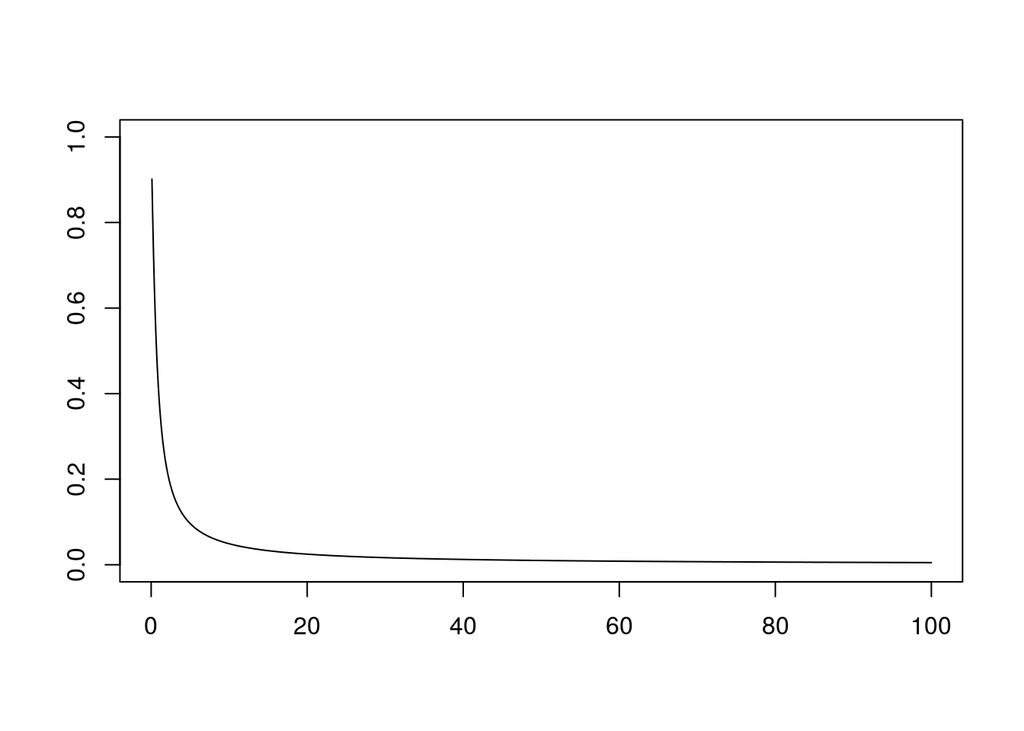

```r
plot(0, type="n", xlab="", ylab="", xlim=c(0, 100), ylim=c(0, 1))
alpha <- seq(0.1, 100, 0.1)
lines(x=alpha, y=1 - 1/(alpha*trigamma(alpha)))
```

“This tells us the obvious, that knowing $\alpha$ improves our estimate of $\lambda$ (a.r.e. is below $1$).”